# Q28-WilliamKennedy-300015367

William Kennedy

2023-11-10

In this exercise, you will further analyze the Wage data set considered throughout this chapter.

```r
Wage = read.csv("Wage.csv")
wage = Wage$wage
age = Wage$age

wage.lm = lm(wage~age,data=Wage)
```

1. Perform polynomial regression to predict wage using age. Use cross-validation to select the optimal degree d for the polynomial. What degree was chosen, and how does this compare to the results of hypothesis testing using ANOVA? Make a plot of the resulting polynomial fit to the data.

```r
library("boot")
```

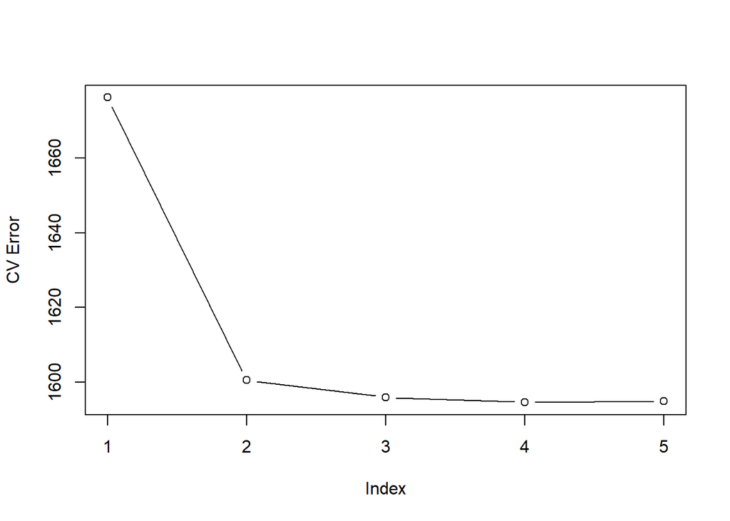

```r
 cv.error <- rep (0, 5)
for (i in 1:5) {
  glm.fit <- glm (wage~poly(age , i), data = Wage)
  cv.error[i] <- cv.glm (Wage , glm.fit)$delta[1]
}
plot(cv.error,type='b',ylab="CV Error")
```

```r
print(cv.error)
```

```
## [1] 1676.235 1600.529 1595.960 1594.596 1594.879
```

The degree with the smallest cross validation error is d=4, which has a cross validation error of 1594.596. However, this is marginally preferable over d=3 and d=5.

```r
fit.1 <- lm(wage~age , data = Wage)
fit.2 <- lm(wage~poly (age , 2), data = Wage)
fit.3 <- lm(wage~poly (age , 3), data = Wage)
fit.4 <- lm(wage~poly (age , 4), data = Wage)
fit.5 <- lm(wage~poly (age , 5), data = Wage)
anova= anova (fit.1, fit.2, fit.3, fit.4, fit.5)

anova
```

|  | Res.Df | RSS | Df | Sum of Sq | F | Pr(>F) |
| --- | --- | --- | --- | --- | --- | --- |
| 1 | 2998 | 5022216 | NA | NA | NA | NA |
| 2 | 2997 | 4793430 | 1 | 228786.010 | 143.5931074 | 2.367734e-32 |
| 3 | 2996 | 4777674 | 1 | 15755.694 | 9.8887559 | 1.679213e-03 |
| 4 | 2995 | 4771604 | 1 | 6070.152 | 3.8098134 | 5.104623e-02 |
| 5 | 2994 | 4770322 | 1 | 1282.563 | 0.8049758 | 3.696820e-01 |

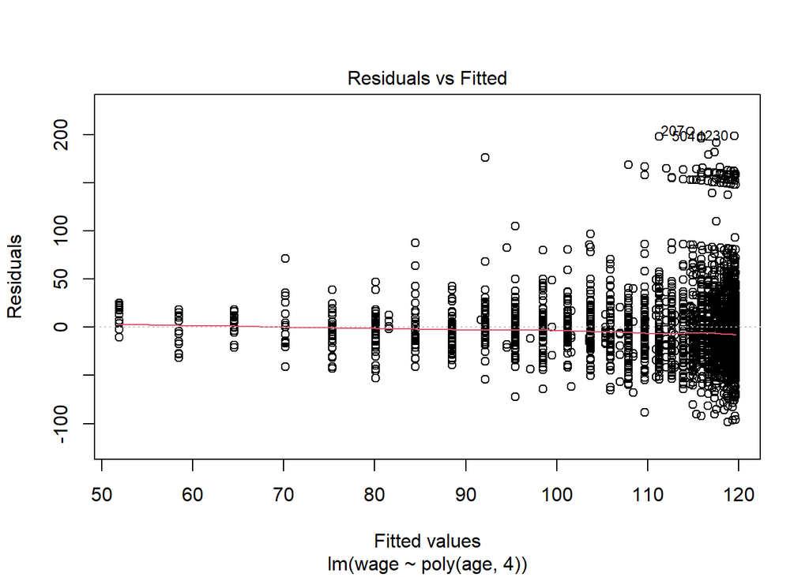

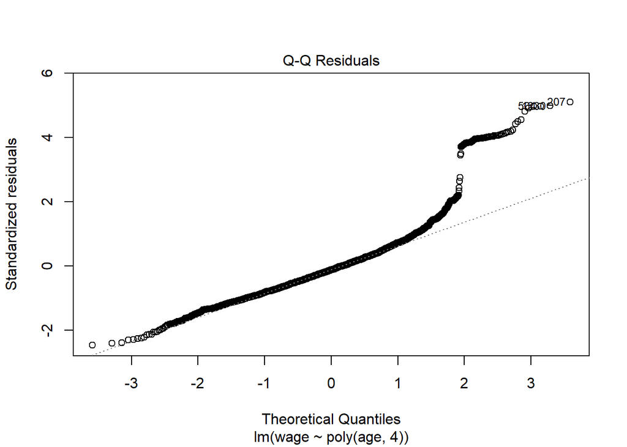

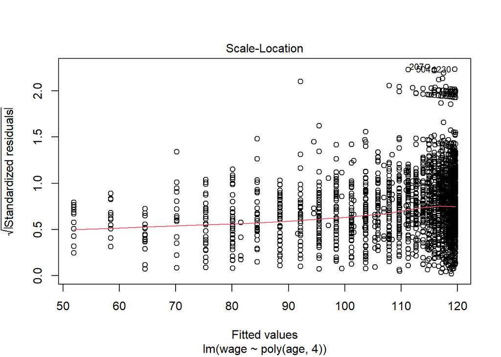

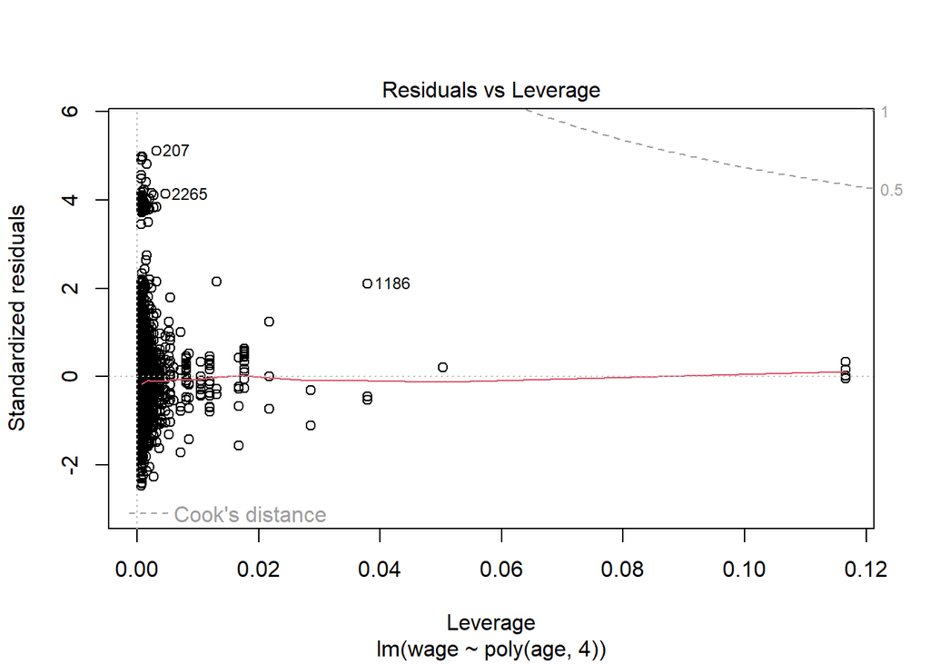

```r
plot(fit.4)
```

Here I used the anova function to perform some hypothesis testing on the five linear models, to determine if they are all the same(null hypothesis is true) or they are different (Null hypothesis is false). You can see that based on the F statistic and P-values that either the cubic or quartic functions are preferable when compared to the other three models.

2. Fit a step function to predict wage using age, and perform cross-validation to choose the optimal number of cuts. Make a plot of the fit obtained.

```r
library('ggplot2')
set.seed(1)
cv.error.cut = rep(NA,19)

for (i in 2:20) {
  Wage$age.cut = cut(Wage$age,i)
  step.fit=glm(wage~age.cut,data=Wage)
  cv.error.cut[i-1]=cv.glm(Wage,step.fit,K=10)$delta[1] # [1]: Std [2]: Bias corrected.
}
cv.error.cut
```

```
##  [1] 1734.489 1684.271 1635.552 1632.080 1623.415 1614.996 1601.318 1613.954
##  [9] 1606.331 1603.465 1604.349 1602.915 1608.731 1603.178 1597.583 1603.909
## [17] 1601.161 1607.540 1608.915
```

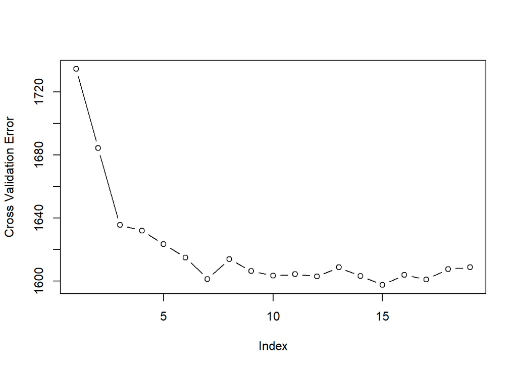

```r
plot(cv.error.cut,type='b',ylab="Cross Validation Error")
```

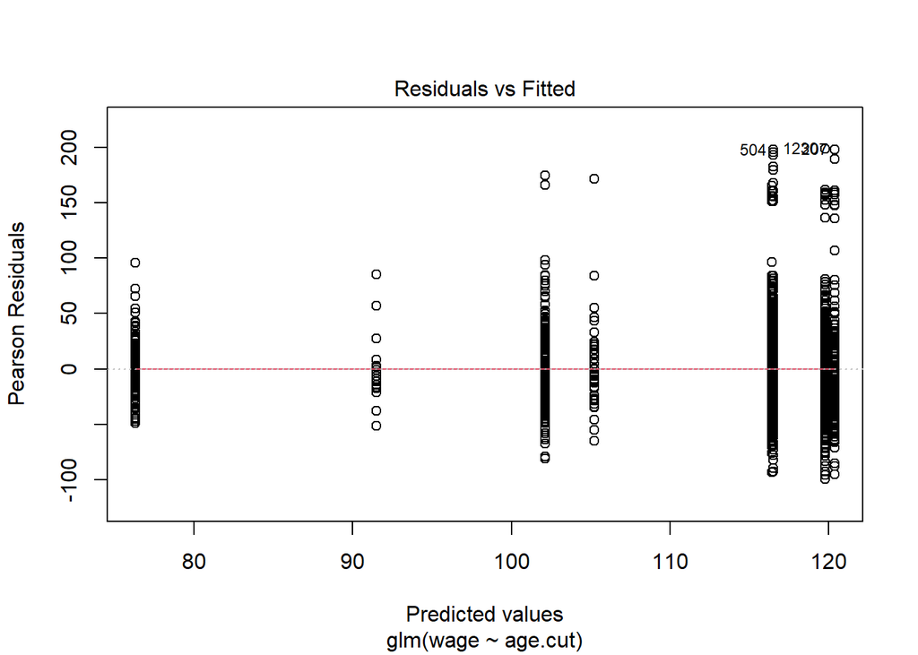

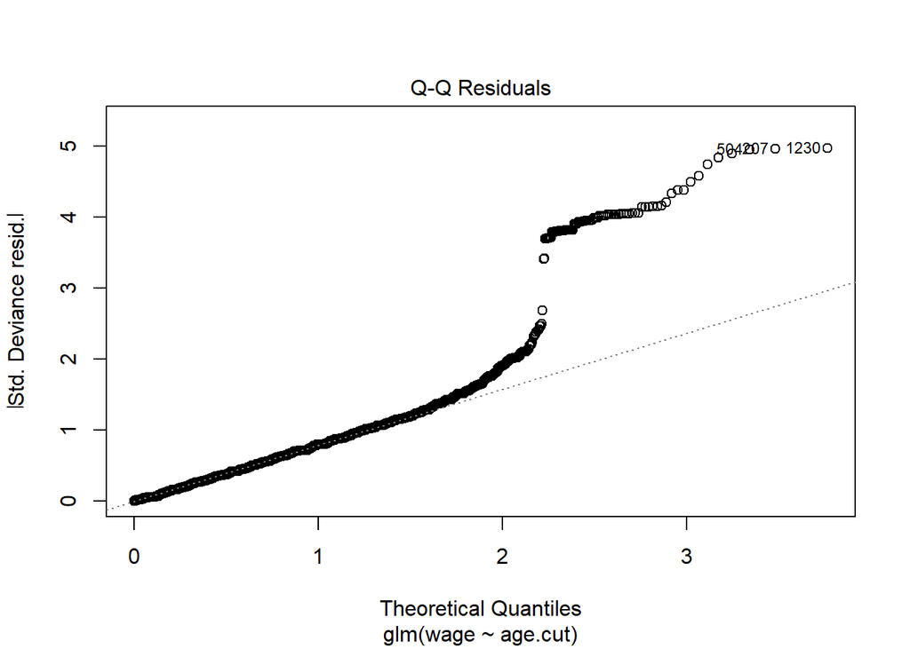

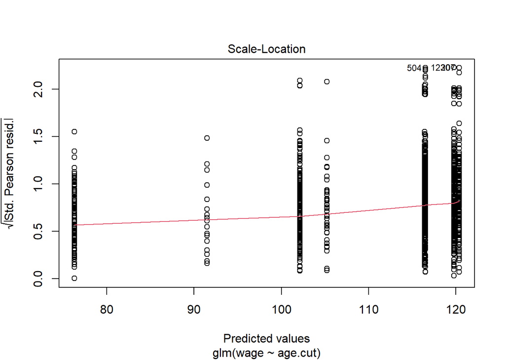

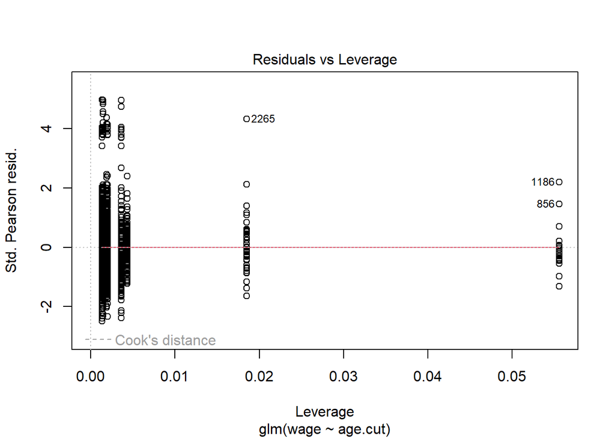

```r
Wage$age.cut = cut(Wage$age, 8)
fit=glm(wage~age.cut,data=Wage)
plot(fit)
```

Q-Q Residuals Plot It can be seen that as for the first and second quantile that our responses are normally distributed, but as the we reach the third quantile and move into the fourth quantile the responses becomes over-dispersed. Also known as a Leptokurtic distribution, this may suggest the results are unreliable.